# 卡布奇诺指数：一杯咖啡要干多久

TidyTuesday · 2026-09-08

作者

zlZayn

发布于

2026年9月20日

# 一杯卡布奇诺的三层账

一杯卡布奇诺要花掉多少分钟工资？这份报告把同一个问题拆成三层：**国家排位**、**贵在哪一侧**、**国家级均值盖住了什么**。三层共用同一份聚合（87 国 × 国家均值），所以图与图之间可以直接对照。

## 数据口径

`cafe.csv` 是 2594 家门店的横截面：每行给出一杯卡布奇诺的价格与当地小时工资，`cappuccino_index.csv` 把它按国聚合成 87 行。**指数 = 60 × 国家平均价格 ÷ 国家平均小时工资**，单位是「买一杯咖啡要干多少分钟」。三张图里的每一个国家级数值都来自这一份聚合，正文引用的数字与图上读数是同一份。

| 字段 | 口径 |
| --- | --- |
| `price` / `hourly_wage` | **本币**原值（`original_currency`，共 65 种） |
| `price_gbp` / `hourly_wage_gbp` | 同一批数字按单套快照汇率折成英镑；**一切跨国比较只用这两列**，`price` / `hourly_wage` 只用来核对本币量级 |
| `index` | 分钟数；`index_as_time` 是它的 `mm:ss` 写法。**分钟数超过 59 时不是时刻而是累计分钟**——277:02 读作 4 小时 37 分（26 国如此）。本报告所有 `mm:ss` 一律向下截到整秒 |
| `urban` / `suburban` / `rural` | 三个**互相独立**的标记，不是三分类：63 行同时命中多个。因此本报告不用它们切分国别 |
| `n`（index 表） | 该国入样的门店数，逐国等于 `cafe.csv` 的国家行数，合计 2594 家 |

`cafe.csv` 覆盖 949 个城市（`city` 有 169 行缺失）。汇率只有一套快照、数据里没有日期列，所以本报告不涉及任何时间趋势。

## 图 1 · 87 国的排位：从 10 分钟到 4 小时 37 分

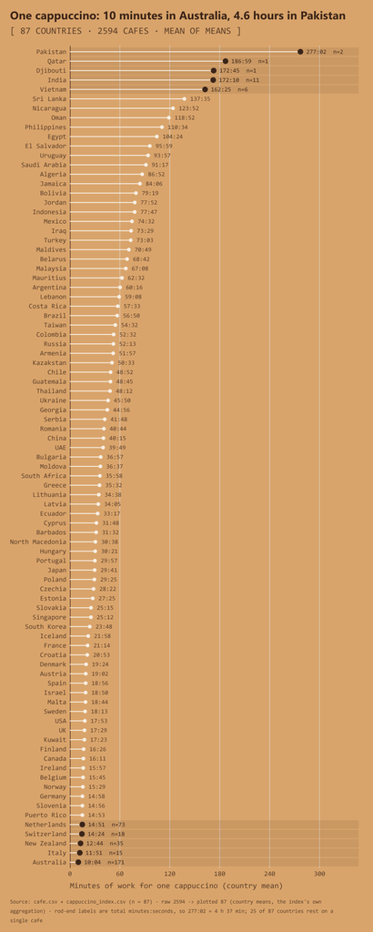

Country ladder of the cappuccino index: the rod end gives the country mean as minutes:seconds of work; top and bottom five countries are banded and their names carry n.

Pakistan 高居榜首（277:02），Australia 最低（10:04），首尾相差 27.5 倍；87 国的中位数是 36:57。分布并不均匀：8 国在 15 分钟以内，26 国超过 1 小时，其中 7 国超过 2 小时。

高亮的 10 国里，两端都要留个心眼：Pakistan 的 `n` 只有 2 家门店，而全表有 25 个国家的指数只建立在 **1 家** 门店上（38 国不超过 3 家）。棒末的 `n=` 只出现在 10 个高亮国，就是因为其余国家里 `n` 小的太多，逐个标出来会把版面压垮——这一层不确定性放到图 3 处理。

## 图 2 · 等工时斜线：贵在哪一侧

同样 87 个国家，把坐标换成「工资」与「价格」两个可观测量的对数，等工时斜线 `y = x · t / 60` 就正好是 `index = t` 的等值线——**散点落在哪条线上，就等于图 1 里的读数**。这是本报告用国家均值而不是中位数的原因：只有均值能让斜线与 `index` 严格重合。

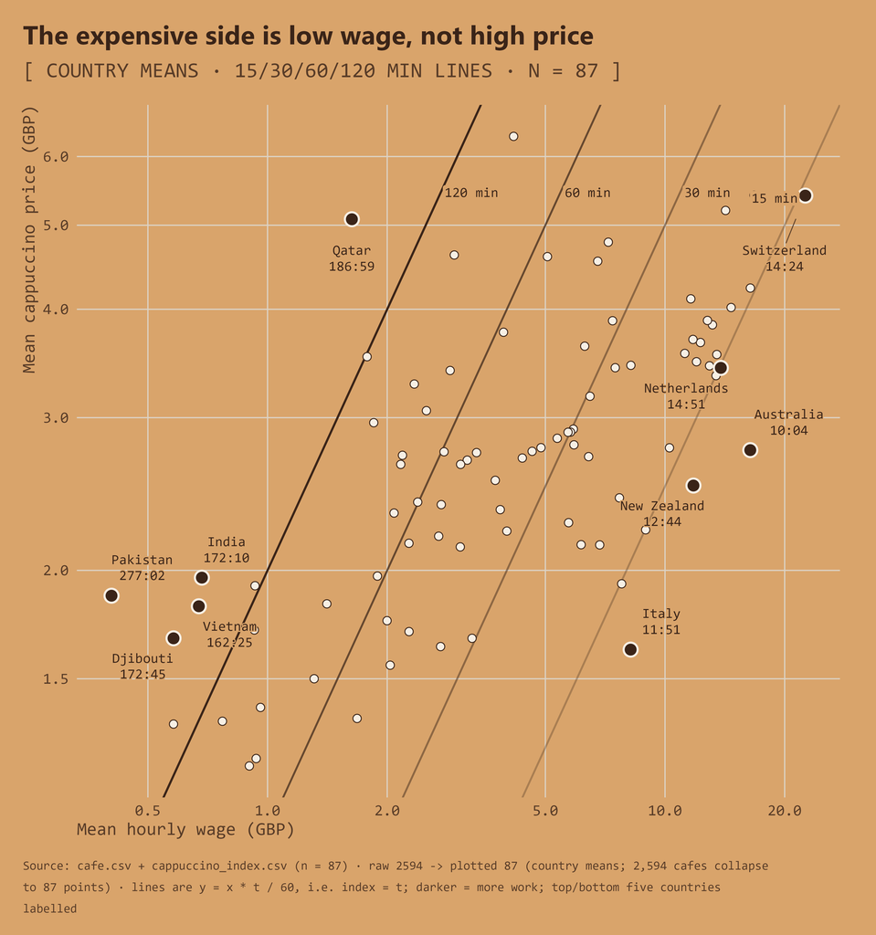

## 图 3 · 国家级均值盖住了什么

前两张图每个国家只有一个点，这个点可能谁都不代表。把门店还原成行：分钟数 `= 60 × price_gbp / hourly_wage_gbp`，只看门店数 `n ≥ 30` 的 13 个国家。

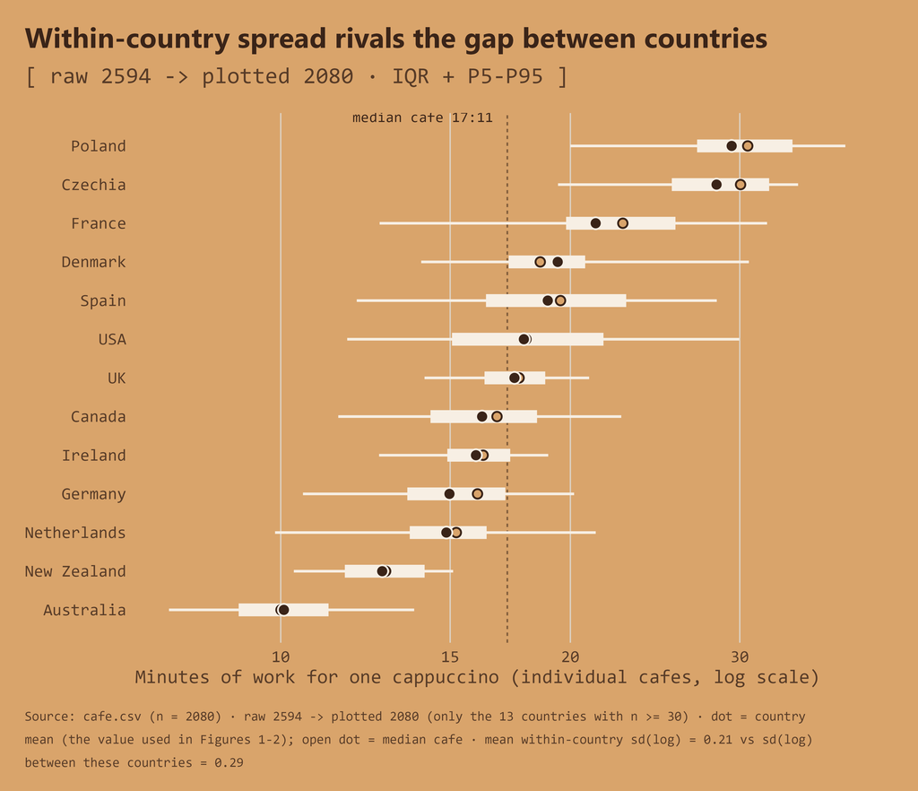

Inside the thirteen best-sampled countries: the country mean tracks the median cafe closely, but individual cafes span about a two-fold range, and within-country spread rivals the spread between countries.

raw 2594 -> plotted 2080 (only the 13 countries with n >= 30)。这 2080 行门店的中位数是 17:11。先看均值能不能代表「典型门店」：在这 13 个样本充足的国家里，国家级均值与中位数门店差得最远的是 Germany（均值 14:58 vs 中位数门店 16:00，6.5%，而这 13 国的中位差距只有 3.0%），所以用均值概括「典型门店」站得住。被抹掉的是**离散**：这些国家最便宜 5% 与最贵 5% 门店的比值中位数是 1.9 倍（最宽的是 USA，2.6 倍）。这 13 国国内的 `sd(log)` 平均 0.21，它们之间的 `sd(log)` 是 0.29：**同一国内部的离散，已经接近国家之间的离散**。所以图 1 的名次只应读作「国家级平均条件」，不代表你走进任意一家门店会看到的时间。

## 数据异常

`hourly_wage_gbp` 最低只有 0.17 英镑/小时（Mumbai, India (INR - Indian Rupee)），低于 1 英镑的 41 家、低于 2 英镑的 101 家。这不是录入错误：这些行的本币工资（如 22 INR/h、135 PKR/h、9 000 IDR/h）与各自币种的量级一致，是低工资经济体的真实值。**不剔除**——它们正是高指数国家（Pakistan 277:02、Qatar 186:59）的来源；代价是这些国家的指数对单店极度敏感。

另一处口径陷阱在棒末标签：`index_as_time` 在分钟数超过 59 时是**累计分钟**，277 分钟会写成 277:02。报告沿用这个格式，并在图注里写明换算。

## 方法与口径

| 项 | 值 |
| --- | --- |
| 数据 | `data/cafe.csv`（2594 × 10）、`data/cappuccino_index.csv`（87 × 6），只读 |
| 本报告聚合 | 按 `country` 求**均值**：`wage = mean(hourly_wage_gbp)`、`price = mean(price_gbp)`、`index = 60 × price / wage`。三张图的国家级数值全部来自这一份 87 行表 |
| 图 3 口径链 | raw 2594 -> plotted 2080 (only the 13 countries with n >= 30)；被排除的 514 行分布在其余 74 个国家，全部因为 `n < 30`，不是数据问题 |
| 币种 | `price` / `hourly_wage` 是本币（`original_currency` 共 65 种）；一切跨国数字用 `*_gbp`。汇率是单套快照，无日期列 |
| 未使用的字段 | `city`（169 行缺失，且图 1、2 是国家级）；`urban` / `suburban` / `rural`（三个标记不互斥、63 行同时命中多个，且 `rural` 只有 160 家门店摊在 16 个国家里） |
| 图内文字 | 一律英文 |